# Class 4

April 26, 2017

## Hello again

## Welcome Back !

These slides: http://www.databrew.cc/class4

## Proud

I am proud of this class.

[figure not shown]

## Impressed

I am impressed with this class.

[figure not shown]

## Excited

I'm excited about what comes next.

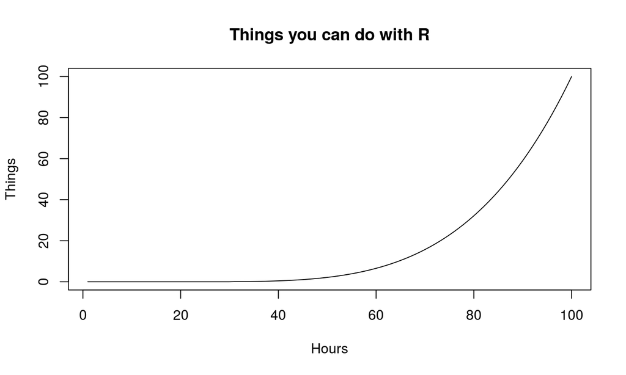

## Today

## Today

- Discussion of last two classes
- Review of `dplyr`
- Making beautiful visualizations
- Merging and joining data

## Discussion of last two classes

- Dates: 10 de maio, 17 de maio
- Focus:

— statistical analysis (modeling)  
— spatial analysis (clustering, distance calculations, geocoding, etc.)  
— fun stuff (sending emails through R, interactive spreadsheets, etc.)  
— web applications (building an interactive web application in R)  
— reproducible research (automated analyses, etc.)  
— visualization  
— data management (merging, cleaning, etc.)  
— practice (work on some real data together)

## Review of dplyr

## Functions

It has 7 useful functions:

- `%>%`
- `arrange`
- `group_by`
- `mutate`
- `summarise`
- `select`
- `filter`

## Some comments

- A different syntax (less quotations, less dollar signs)
- Uses dataframes, more than variables
- Very fast

## `%>%`

This means "then".

```r
chicken %>%
  kill it %>%
  cook it %>%
  eat it
```

## `arrange`

## `group_by`

## `mutate`

## `summarise`

## `select`

## `filter`

## Let's practice

I like animals. Let's get some data about them.

```r
animals <- MASS::Animals
```

## Some questions

1. Use `head` to see what our data looks like.
2. Create a plot with the `body` variable on the x-axis and the `brain` variable on the y-axis.
3. Create a variable called `name`. This will simply be the `row.names(animals)`.
4. Create an object called `animals`. This will be `animals` (over-write), but use `mutate` to divide `brain` by 1,000 in order to convert from grams to kilograms.

## Questions (continued)

1. Create an object called `animals`. This will be `animals` (over-write), but use `mutate` to create an object called `brain_to_body` which will be brain weight divided by body weight.
2. Create an object called `animals`. This will be `animals`, but use `arrange` to order by our new variable (`brain_to_body`).
3. Which animal has the greatest brain to body ratio? And the least?

## Questions (continued)

1. Use `mutate` to create a variable in `animals` which will be called `intelligence`. If the `brain_to_body` ratio is greater than 0.15, let's say "smart"; otherwise, let's say "stupid". Hint: use `ifelse`
2. Create an object called `x`. This will be `animals`, then `group_by` the `intelligence` variable, then use `summarise` to create two new variables: (1) the number of animals, and (2) the average body size of those animals.

## More practice

Let's get some data on birth weight.

```r
bw <- MASS::birthwt
```

## Questions on birthweight

1. Use `head` to look at our data.
2. Create a histogram to show the distribution of birthweight.
3. Create a plot showing the correlation between `age` (of mother) and the birth weight.
4. In `bw`, use `mutate` to create a new variable called `size`. If the birth weight is greater than 2500, call it "big"; otherwise, "small".
5. Create an object called `x`. This will be `bw`, then group by our `smoke` varible AND then use `summarise` to create a new variable called `average_grams` which will be the average birth weight.
6. What is the effect of smoking on birth weight?

## More practice

Let's get world bank data for Mozambique.

```r
library(cism)
library(dplyr)
wb <- cism::wb
```

## Some questions

1. Create an object called `phone`. This will be `wb` but `filter`ed so as to only include those rows where the `indicator_name` is "Mobile cellular subscriptions".
2. Make a plot of the number of of cell phone subscriptions.
3. Create an object called `mulungos`. This will be `wb` but `filter`ed so as to only include those rows where the `indicator_name` is ""International tourism, number of arrivals" AND the year is greater than 2000.
4. Make a plot of the number of tourists.
5. Run `sort(unique(wb$indicator_name))` to take a look at all the different data types in `wb`.
6. Pick one and plot it.

## Beautiful visualizations

## Does being pretty matter?

[figure not shown]

## Pie vs. Bar

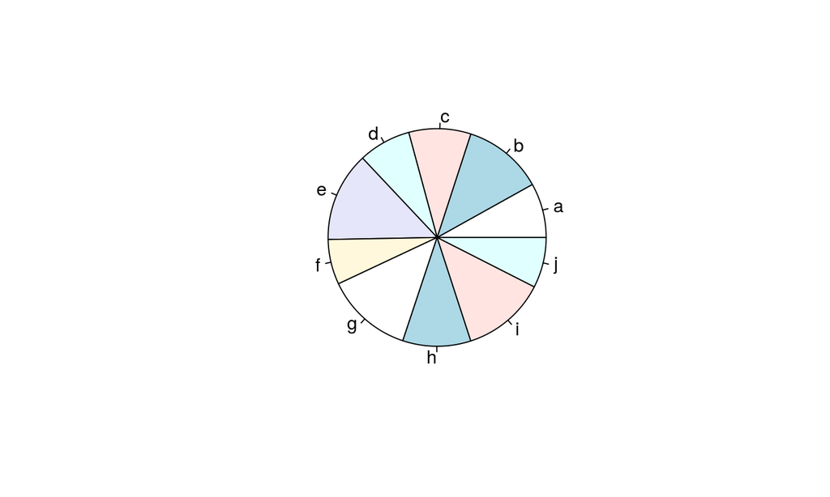

## Pie vs. Bar

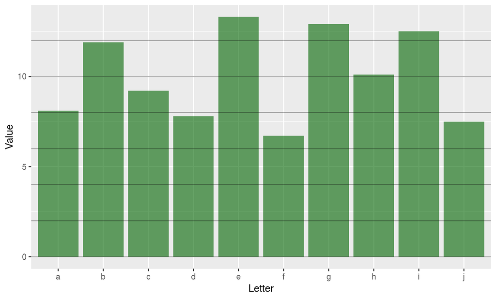

## Boxplot vs violin chart

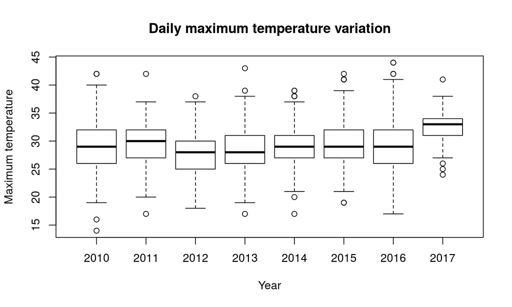

## Boxplot vs violin chart

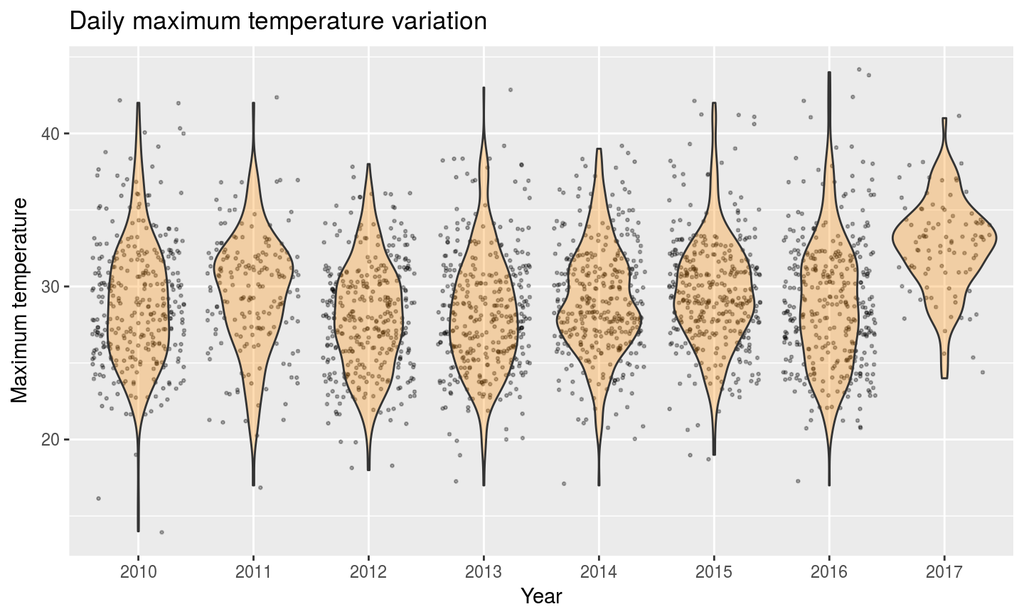

## Does being pretty matter?

Yes.

1. Effiency in conveying information (Information to time ratio).
2. ATTRACTiveness (increase the amount of time visualized).

## Good or bad?

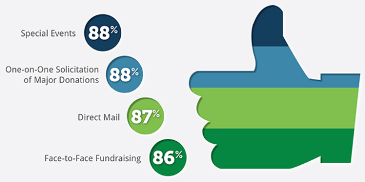

## Good or bad?

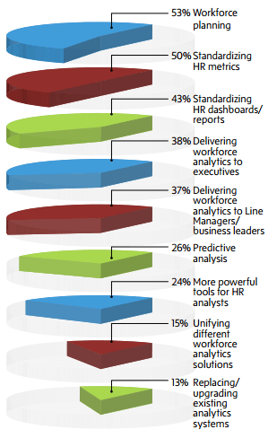

## Good or bad?

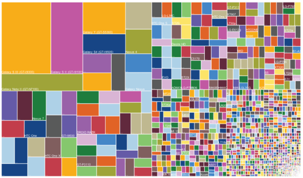

## Good or bad?

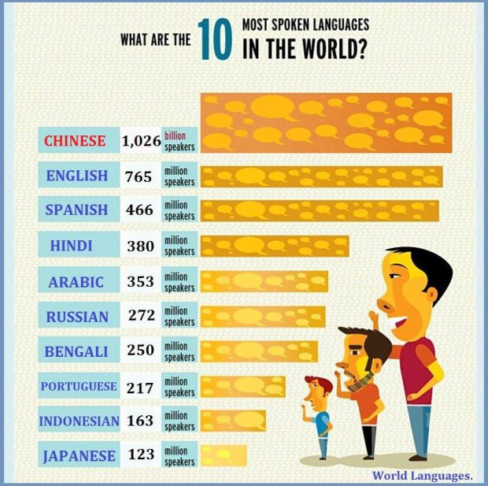

## Good or bad?

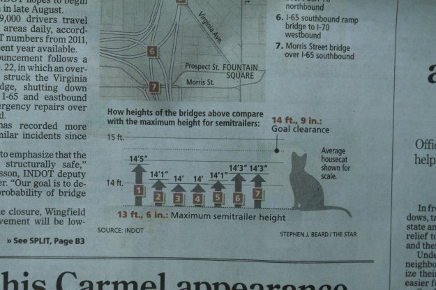

## Good or bad?

[figure not shown]

## Good or bad?

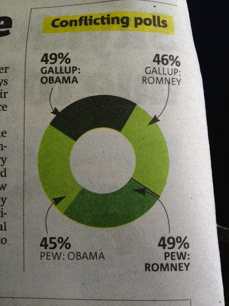

## Good or bad?

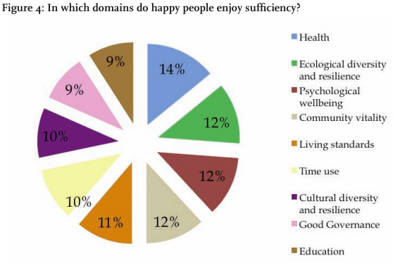

## Good or bad?

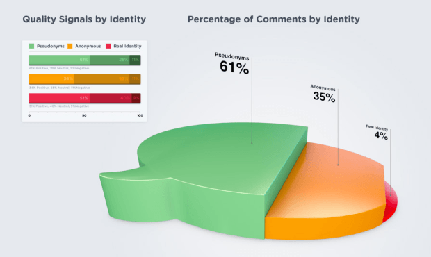

## Good or bad?

[figure not shown]

## Good or bad?

[figure not shown]

## Good or bad?

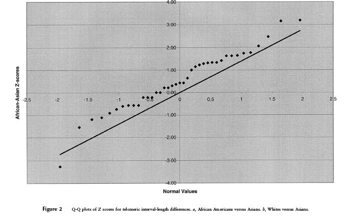

## Good or bad?

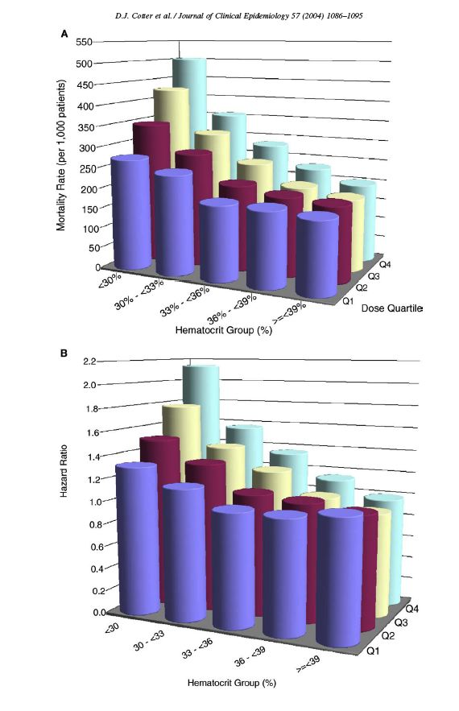

## Good or bad?

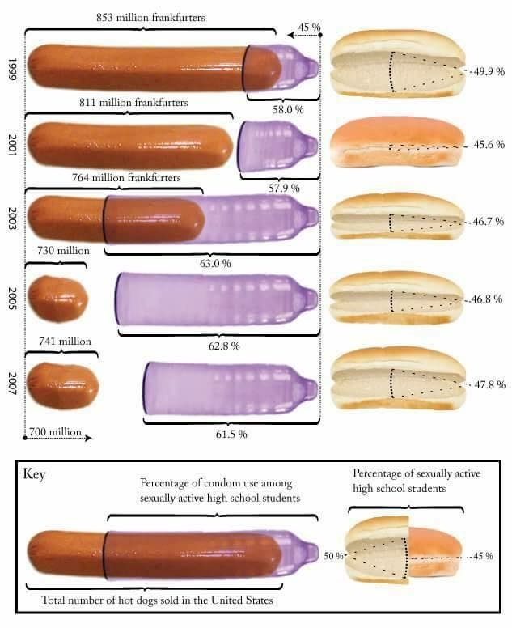

## Good or bad?

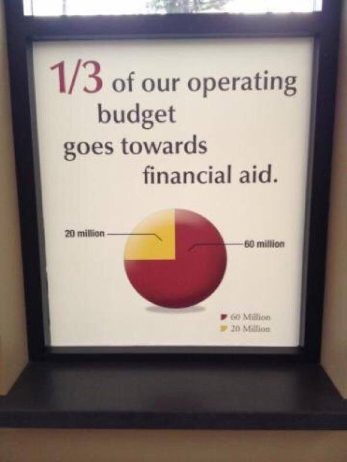

## Good or bad?

[figure not shown]

## Video on data visualization

https://ted.com/talks/david_mccandless_the_beauty_of_data_visualization

## `ggplot2`

```r
library(ggplot2)
library(ggthemes)
library(cism)
library(dplyr)
```

## First plot

[figure not shown]

```r
ggplot()
```

## Add a title

[figure not shown]

```r
ggplot() +
  labs(title = 'This is a title')
```

## Add a subtitle and some axes

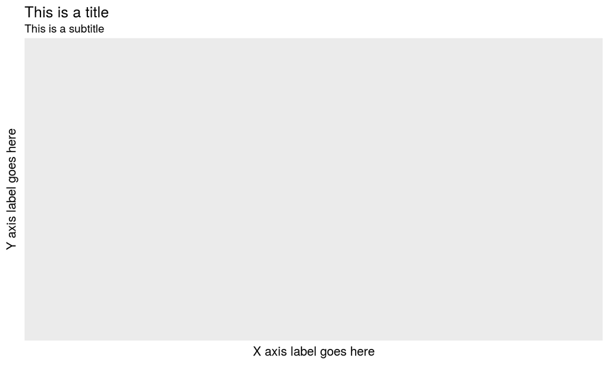

```r
ggplot() +
  labs(title = 'This is a title',
       subtitle = 'This is a subtitle',
       x = 'X axis label goes here',
       y = 'Y axis label goes here')
```

## Let's get some data to plot

```r
survey <- MASS::survey
# Remove those without sex
survey <- survey %>%
  filter(!is.na(Sex))
```

## Make a histogram

## Make the histogram pretty

Add a title, subtitle, fill, color, and transparency

## Make the histogram even more pretty

Add a theme

`theme_economist()`, `theme_wsj`, `theme_cism`, `theme_bw`, etc.

## Single variable: categorical

Make a barplot

## Make the barplot pretty

Use arguments like `color`, `fill`, `alpha`, `labs` (title, subtitle, x, y)

## Facet the barplot

Use arguments like `color`, `fill`, `alpha`, `labs` (title, subtitle, x, y)

## Facet the histogram

Create a histogram of age, and facet it by sex.

## Use `geom_density` instead of histogram

Create a histogram of pulse, and facet it by sex.

## Instead of faceting, overlap

Create a histogram of age, and facet it by sex.

## Create a barplot of smoking

Facet it by sex.

## Create a two-variable chart

We're going to use two continuous variables

## Change the color and alpha

## Make the color by sex

## Make a point chart with two variables

On the x-axis, we'll use a categorical variable (Sex). On the y-axis, a continuous one (Pulse).

## Use `geom_jitter` instead of `geom_point`

## Add another layer: `geom_boxplot`

## Add another layer: `geom_violin`

## Make it prettier

Use alpha, fill, color, etc.

## Questions

1. Use `ggplot` to create a two variable scatterplot of longitude and latitude.
2. Use `ggplot` to create a histogram of age.
3. Use `ggplot` to create a "density" chart of age.
4. Use `ggplot` to create a two variable jittered point and violin chart of `sex` and `age`
5. With the same chart you just created, use `facet_wrap` to create to create one chart for each kind of `floor_material`

## More questions

Let's get some new data

```r
frangos <- databrew::frangos
```

## More questions

1. Make a simple x-y chart of days and grams
2. Make the same chart, but make the color be a reflection of the diet
3. Make the same chart, but add a `geom_line()` argument to it.
4. Make the same chart, but remove the `geom_line()` and add a `geom_smooth()`
5. Make a new chart with days on the x axis, grams on the y axis, and facet it by diet.

## More questions

Let's use the census data.

1. Create a plot of everyone's locations.
2. Create a plot of everyone's locations, but color the points by `sex`
3. Create a plot of everyone's locations, color the points by `age`, and facet the plot by `wash_after_poop`.
4. Create a plot of everyone's locations, color the points by `celular`, make the point size a reflection of age, and facet the points by TWO variables using `facet_grid`: `car` and `pigs`
5. Make a density chart of the age variable in the census, and facet the chart by floor material.

## More questions

Let's use our census data again.

1. Create two new variables using `mutate`: (1) `longitude_round` and (2) `latitude_round`. This should be a rounding to one digit of the coordinates.

```r
census <-
  census %>%
  mutate(longitude_round = round(longitude, digits = 1),
         latitude_round = round(latitude, digits = 1))
```

## More questions

1. Create an object called `x`. This will be the `census`, grouped by `longitude_round` and `latitude_round`, and then summarised to create a variable called `people` with the number of people.
2. Use `arrange` to find the least populated area.
3. Create a plot of all our people's locations, and ADD to that plot our rounded coordinates, with point size should be a reflection of the number of people.